# Check for discordant lanes

2016-08-03

**Last updated:** 2016-08-03

**Code version:** e6fdf4fc6d4af353eac59551e83c00534d1cfac2

```r
library("knitr")
opts_chunk$set(cache = FALSE)
```

## Setup

```r
library("data.table")
library("dplyr")
library("edgeR")
library("gplots")
library("ggplot2")
theme_set(theme_bw(base_size = 12))
theme_update(panel.grid.minor.x = element_blank(),
             panel.grid.minor.y = element_blank(),
             panel.grid.major.x = element_blank(),
             panel.grid.major.y = element_blank())
```

Input raw counts file.

```r
data_raw <- fread("../data/subread-counts-per-lane.txt", data.table = FALSE)
data_raw[1:5, 1:7]
```

```
##   individual  status treatment flow_cell lane ENSG00000186092
## 1        c01 contact  infected H7LVWBBXX   l2               0
## 2        c01 contact  infected HCMF5BBXX   l2               0
## 3        c01 contact  infected HCN77BBXX   l2               0
## 4        c01 contact      none H7LVWBBXX   l2               0
## 5        c01 contact      none HCMF5BBXX   l2               0
##   ENSG00000279928
## 1               0
## 2               0
## 3               1
## 4               0
## 5               0
```

Split annotation and counts.

```r
anno <- data_raw %>% select(individual:lane)
counts <- data_raw %>% select(starts_with("ENSG")) %>% t()
anno$id <- paste(anno$individual, anno$treatment, anno$flow_cell, sep = ".")
colnames(counts) <- anno$id
```

Standardize by library size.

```r
counts_cpm <- cpm(counts, log = TRUE)
```

## First pass

Perform PCA.

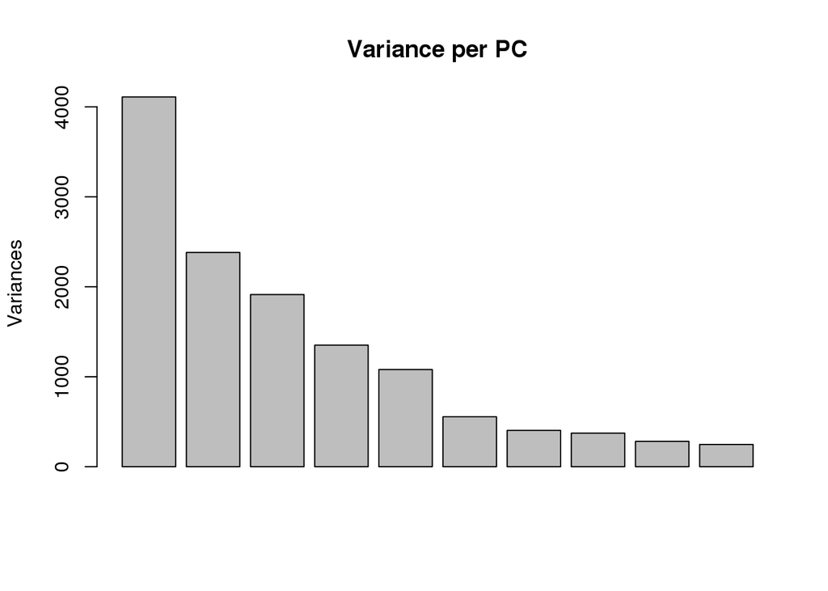

```r
pca <- prcomp(t(counts_cpm), scale. = TRUE)
variances <- pca$sdev^2
explained <- variances / sum(variances)
plot(pca, main = "Variance per PC")
```

```r
pca_data <- cbind(anno, pca$x)
```

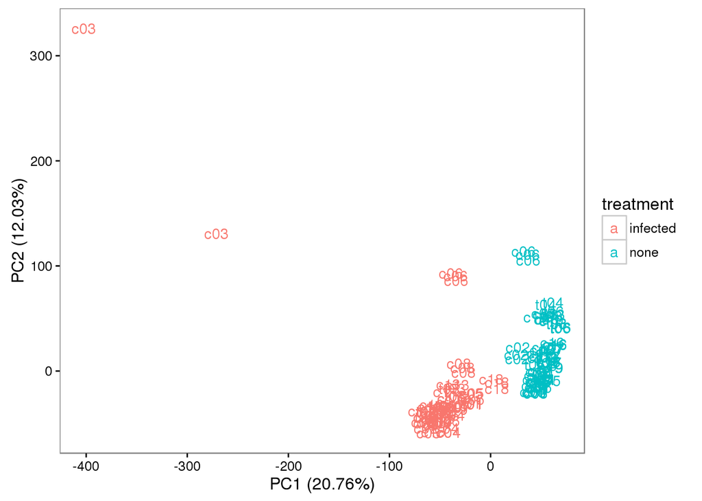

```r
ggplot(pca_data, aes(x = PC1, y = PC2, color = treatment)) +
  geom_text(aes(label = individual)) +
  labs(x = sprintf("PC%d (%.2f%%)", 1, round(explained[1] * 100, 2)),
       y = sprintf("PC%d (%.2f%%)", 2, round(explained[2] * 100, 2)))
```

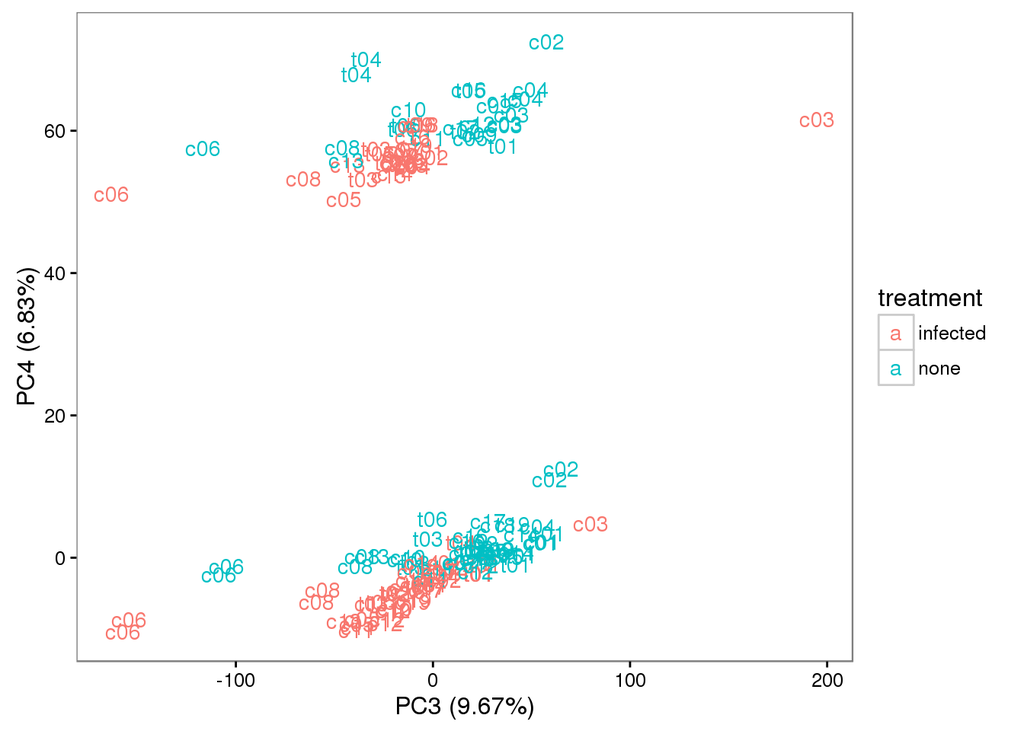

```r
ggplot(pca_data, aes(x = PC3, y = PC4, color = treatment)) +
  geom_text(aes(label = individual)) +
  labs(x = sprintf("PC%d (%.2f%%)", 3, round(explained[3] * 100, 2)),
       y = sprintf("PC%d (%.2f%%)", 4, round(explained[4] * 100, 2)))
```

Perform hierachical clustering.

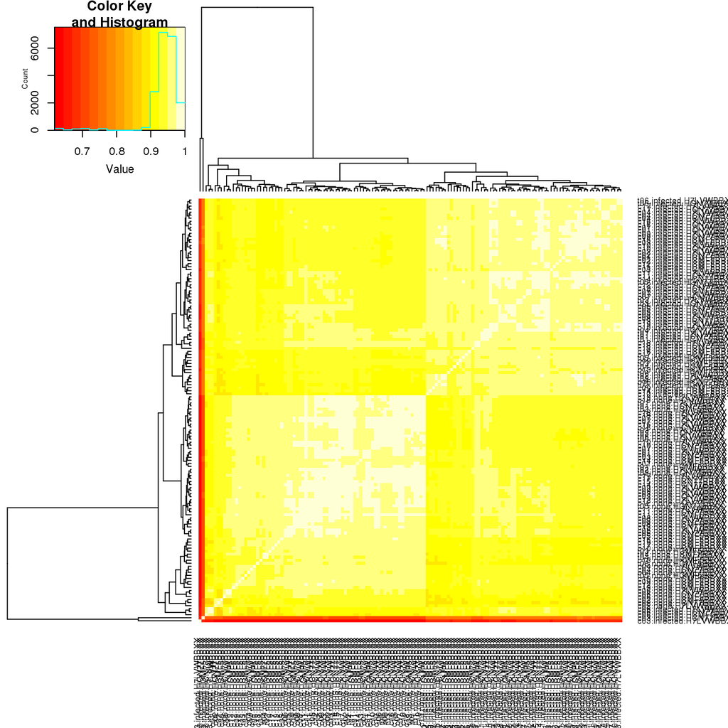

```r
counts_cor <- cor(counts_cpm)
clust <- heatmap.2(counts_cor, trace = "none", margins = c(7, 7))
```

From the PCA and hierarchical clustering, there are two main outliers:

```r
(outliers <- colnames(counts_cor)[clust$colInd[1:2]])
```

```
## [1] "c03.infected.H7LVWBBXX" "c03.infected.HCN77BBXX"
```

This is strange. Why would two lanes of sequencing from this sample be different from the third? This is unexpected because they are from the same library preparation. I suspected this was due to sequencing depth. This is because 03-contact-infected was one of the three samples that was over-sequenced in the first round. After adjusting the amount of 03-contact-infected in the master mix, very little was sequenced in the subsequent two rounds.

```r
depth <- colSums(counts)
depth <- sort(depth)
summary(depth)
```

```
##      Min.   1st Qu.    Median      Mean   3rd Qu.      Max.
##     25630   3115000   8354000  12540000  12640000 161400000
```

```r
head(depth)
```

```
## c03.infected.H7LVWBBXX c03.infected.HCN77BBXX     c02.none.HCN77BBXX
##                  25628                  49055                 777781
##     c02.none.H7LVWBBXX     c02.none.HCMF5BBXX     c18.none.HCMF5BBXX
##                 908128                 935377                1237663
```

```r
tail(depth)
```

```
## t05.infected.HCN77BBXX     c13.none.HCN77BBXX c11.infected.H7LVWBBXX
##               35750684               38888578               40206096
## c03.infected.HCMF5BBXX c15.infected.HCMF5BBXX     c11.none.HCMF5BBXX
##              128561002              148875764              161408985
```

This was clearly the reason. It’s first lane was one of the most highly sequenced, and its two subsequent lanes were the two least sequenced. This is concordant with the sequencing summary statistics provided by the core.

## Second pass

Becuase they are outliers due to depth, and not a problem with the library itself, I think it makes sense to keep them in the final analysis. However, in order to better investigate differences across lanes, I remove them here.

```r
counts_cpm <- counts_cpm[, !(colnames(counts_cpm) %in% outliers)]
anno <- anno[!(anno$id %in% outliers), ]
```

Perform PCA.

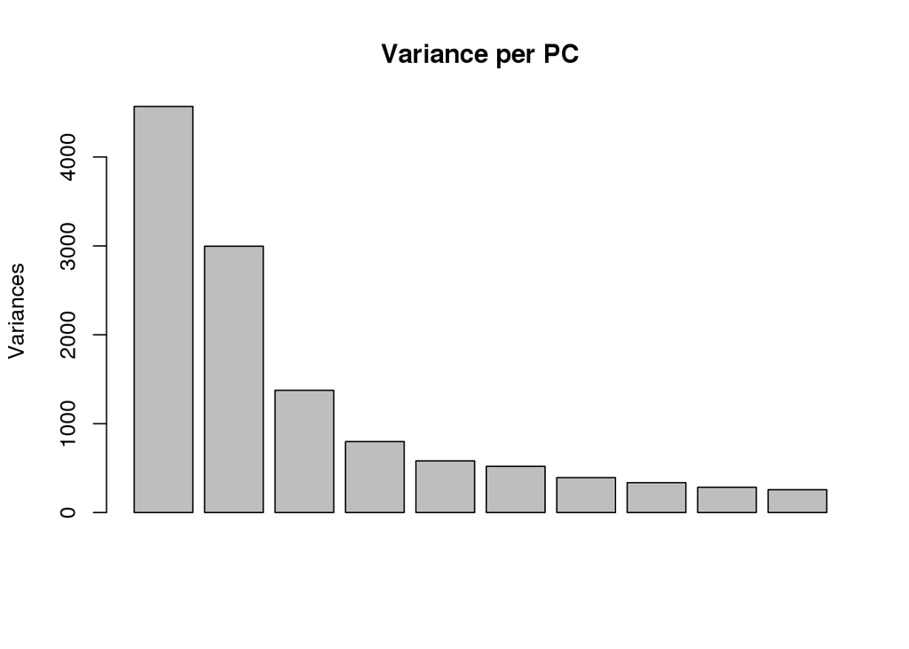

```r
pca <- prcomp(t(counts_cpm), scale. = TRUE)
variances <- pca$sdev^2
explained <- variances / sum(variances)
plot(pca, main = "Variance per PC")
```

```r
pca_data <- cbind(anno, pca$x)
```

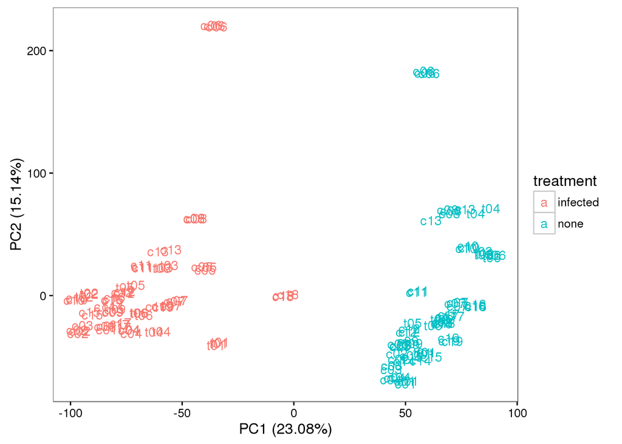

```r
ggplot(pca_data, aes(x = PC1, y = PC2, color = treatment)) +
  geom_text(aes(label = individual)) +
  labs(x = sprintf("PC%d (%.2f%%)", 1, round(explained[1] * 100, 2)),
       y = sprintf("PC%d (%.2f%%)", 2, round(explained[2] * 100, 2)))
```

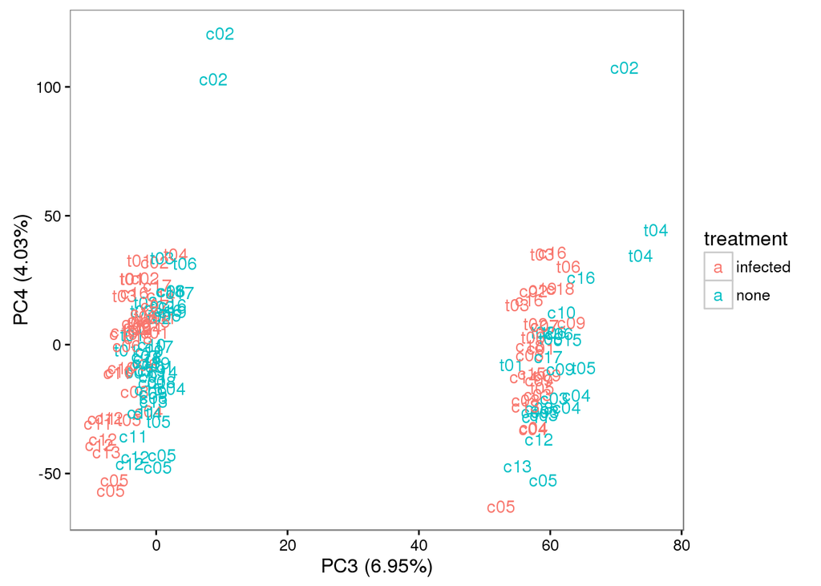

```r
ggplot(pca_data, aes(x = PC3, y = PC4, color = treatment)) +
  geom_text(aes(label = individual)) +
  labs(x = sprintf("PC%d (%.2f%%)", 3, round(explained[3] * 100, 2)),
       y = sprintf("PC%d (%.2f%%)", 4, round(explained[4] * 100, 2)))
```

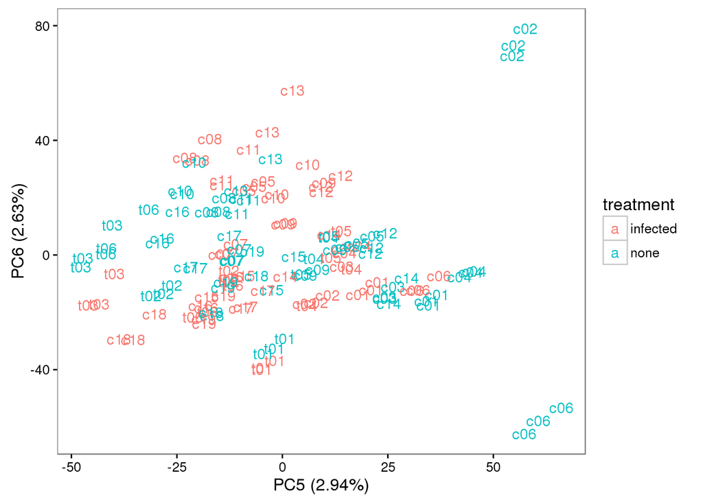

```r
ggplot(pca_data, aes(x = PC5, y = PC6, color = treatment)) +
  geom_text(aes(label = individual)) +
  labs(x = sprintf("PC%d (%.2f%%)", 5, round(explained[5] * 100, 2)),
       y = sprintf("PC%d (%.2f%%)", 6, round(explained[6] * 100, 2)))
```

Perform hierachical clustering.

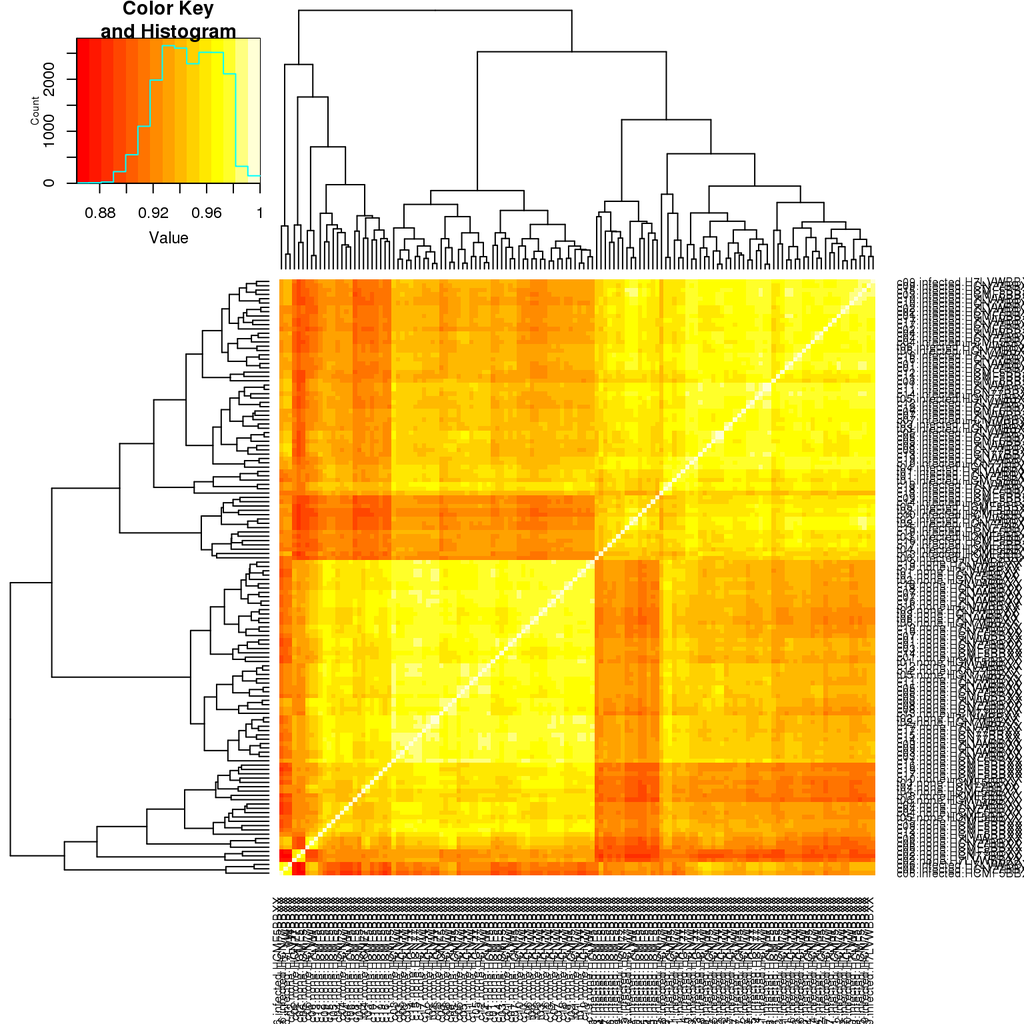

```r
counts_cor <- cor(counts_cpm)
clust <- heatmap.2(counts_cor, trace = "none", margins = c(7, 7))
```

There are three main clusters. The second is clearly the controls (“none”) and the third is clearly the infected samples. The first cluster are the misfits.

```r
(misfits <- colnames(counts_cor)[clust$rowInd[1:26]])
```

```
##  [1] "c06.infected.HCMF5BBXX" "c06.infected.HCN77BBXX"
##  [3] "c06.infected.H7LVWBBXX" "c02.none.H7LVWBBXX"
##  [5] "c02.none.HCN77BBXX"     "c02.none.HCMF5BBXX"
##  [7] "c06.none.HCMF5BBXX"     "c06.none.HCN77BBXX"
##  [9] "c06.none.H7LVWBBXX"     "c13.none.HCMF5BBXX"
## [11] "c12.none.HCMF5BBXX"     "c09.none.HCMF5BBXX"
## [13] "c15.none.HCMF5BBXX"     "t05.none.HCMF5BBXX"
## [15] "c04.none.HCMF5BBXX"     "c04.none.HCN77BBXX"
## [17] "c04.none.H7LVWBBXX"     "t06.none.HCMF5BBXX"
## [19] "c18.none.HCMF5BBXX"     "t04.none.HCMF5BBXX"
## [21] "t04.none.HCN77BBXX"     "t03.none.HCMF5BBXX"
## [23] "c10.none.HCMF5BBXX"     "c17.none.HCMF5BBXX"
## [25] "c19.none.HCMF5BBXX"     "c16.none.HCMF5BBXX"
```

The first 3 sets are not surprising given the PCA results. All 3 replicates of c06.infected, c06.none, and c02.none are in this cluster, consistent with them being outliers in the PCA. The others in this cluster are harder to interpret. The only other one with all 3 replicates represented is c04.none.

```r
table(unlist(strsplit(misfits, ".H")))
```

```
##
##     7LVWBBXX     c02.none     c04.none c06.infected     c06.none
##            4            3            3            3            3
##     c09.none     c10.none     c12.none     c13.none     c15.none
##            1            1            1            1            1
##     c16.none     c17.none     c18.none     c19.none     CMF5BBXX
##            1            1            1            1           17
##     CN77BBXX     t03.none     t04.none     t05.none     t06.none
##            5            1            2            1            1
```

Maybe it is a sequencing depth issue again.

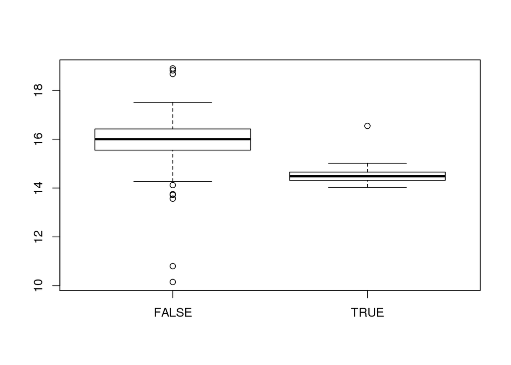

```r
misfits_unknown <- misfits[!(substr(misfits, 1, 3) %in% c("c06", "c02"))]
misfit_factor <- ifelse(names(depth) %in% misfits_unknown, TRUE, FALSE)
boxplot(log(depth) ~ misfit_factor)
```

It appears that sequencing depth is contributing to the issue.